# Basis expansion

Tedoiler

02/12/2021

https://bobby.gramacy.com/surrogates/splines.html

## Basis expansions

Suppose that we have the classical linear model $Y = f(x) + \varepsilon$

We aim to transform the data matrix $X$ to a higher dimension. We create $h_m(x): \mathbb{R}^p \to \mathbb{R}$, the $m$-th transformation of $x$ for $m=1,\dots, M$ Thus we can substitute $f(x)$ with an function of the form.
$$f(x) = \sum_{m=1}^M \beta_m h_m(x)$$
This is a **linear basis expansion** of $x$

Consider that we have some data that are being generated from some underlying sinusoidal function.

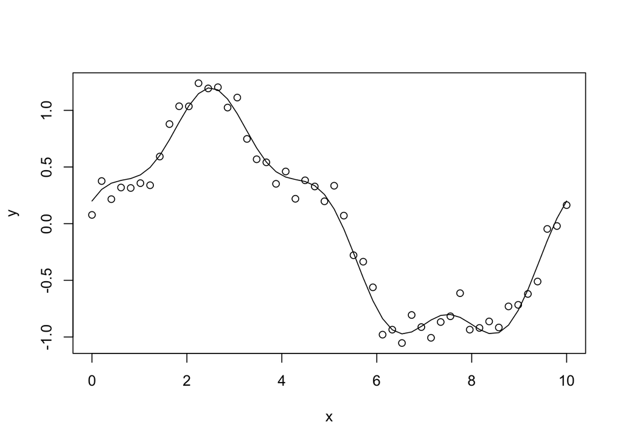

```r
x <- seq(0,10,length=50)
y_true <- sin(pi*x/5) + 0.2*cos(4*pi*x/5)
y <- y_true + rnorm(length(y_true), sd=0.1)
plot(x,y)
lines(x, y_true)
```

##### Constant Basis

```r
knot_1 <- x[round(length(x)/3)]
knot_2 <- x[round(2*length(x)/3)]
xi <- c(knot_1,knot_2)
hc_1 <- function(x) {as.numeric(x < xi[1])}
hc_2 <- function(x) {as.numeric(x >= xi[1] & x < xi[2])}
hc_3 <- function(x) {as.numeric(x >= xi[2])}

H_c <- data.frame(cbind(hc_1(x), hc_2(x), hc_3(x)))
names(H_c) <- paste0("hc", 1:3)
```

We now can fit

```r
pc_fit <- lm(y~.-1, data=H_c)
```

and create a predictive grid and the true output for comparison.

```r
xx <- seq (-1,11, length=199)
HH_constant <- data.frame(cbind(hc_1(xx), hc_2(xx), hc_3(xx)))
names(HH_constant) <- paste0('hc', 1:3)
yytrue <- (sin(pi*xx/5) + 0.2*cos(4*pi*xx/5))
```

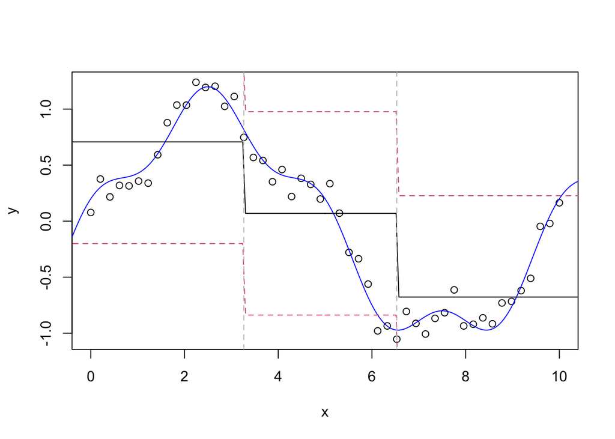

```r
pc <- predict(pc_fit, newdata=HH_constant, interval='prediction')
plot(x,y)
lines(xx, yytrue, col="blue")
lines(xx, pc[,1])
lines(xx, pc[,2], col=2, lty=2)
lines(xx, pc[,3], col=2, lty=2)
abline(v=xi, col="gray", lty=2)
```

##### Linear Basis

```r
H_linear <- cbind(H_c, hc_1(x)*x, hc_2(x)*x, hc_3(x)*x)
names(H_linear)[4:6] <- paste0("hl", 1:3)
pl_fit <- lm(y~.-1, data=H_linear)
```

Create a predictive grid and the true output for comparison.

```r
HH_linear <- cbind(HH_constant, hc_1(xx)*xx, hc_2(xx)*xx, hc_3(xx)*xx)
names(HH_linear)[4:6] <- paste0("hl", 1:3)
pl <- predict(pl_fit, newdata=HH_linear, interval='prediction')
```

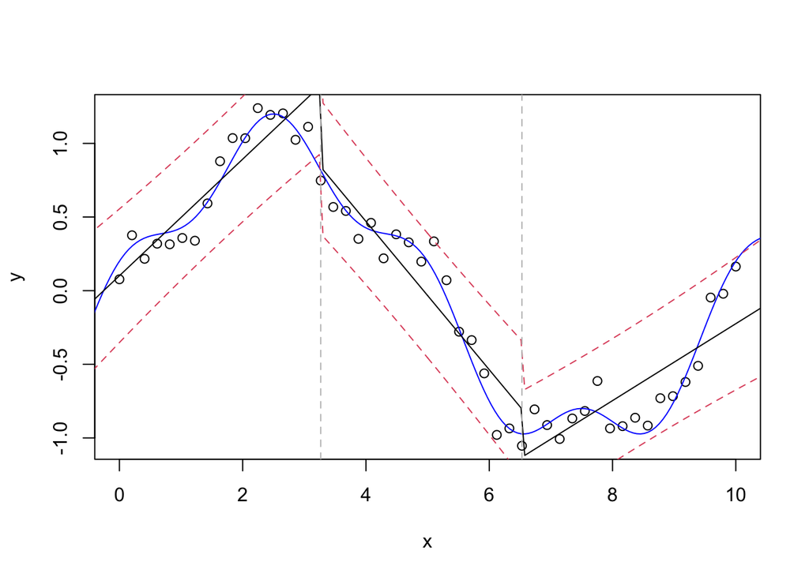

```r
plot(x,y)
lines(xx, yytrue, col="blue")
lines(xx, pl[,1])
lines(xx, pl[,2], col=2, lty=2)
lines(xx, pl[,3], col=2, lty=2)
abline(v=xi, col="gray", lty=2)
```

This seams like a much better fit for the function. However, it still has a major issue. By examining the area around the knots, we see that the predicting function behaves weirdly. Therefore, we need to enforce it to be **continuous**.

#### Enforcing Continuity

We first create a ReLU function

```r
relu <- function(x){
  x[x<0] <- 0
  return(x)
}
```

And now we create a design from that basis

```r
H_lc <- data.frame(rep(1, length(x)), x, relu(x-xi[1]), relu(x-xi[2]))
names(H_lc) <- paste0("hlc", 1:4)
H_lc
```

```
##    hlc1       hlc2      hlc3      hlc4
## 1     1  0.0000000 0.0000000 0.0000000
## 2     1  0.2040816 0.0000000 0.0000000
## 3     1  0.4081633 0.0000000 0.0000000
## 4     1  0.6122449 0.0000000 0.0000000
## 5     1  0.8163265 0.0000000 0.0000000
## 6     1  1.0204082 0.0000000 0.0000000
## 7     1  1.2244898 0.0000000 0.0000000
## 8     1  1.4285714 0.0000000 0.0000000
## 9     1  1.6326531 0.0000000 0.0000000
## 10    1  1.8367347 0.0000000 0.0000000
## 11    1  2.0408163 0.0000000 0.0000000
## 12    1  2.2448980 0.0000000 0.0000000
## 13    1  2.4489796 0.0000000 0.0000000
## 14    1  2.6530612 0.0000000 0.0000000
```

[output cut: 36 more lines]

Fit the transformed data

```r
plc_fit <- lm(y~.-1, data=H_lc)
```

And make predictions

```r
HH_lc <- rep(1,length(xx))
HH_lc <- cbind(HH_lc, xx)
HH_lc <- cbind(HH_lc, relu(xx-xi[1]))
HH_lc <- data.frame(cbind(HH_lc, relu(xx-xi[2])))
names(HH_lc) <- paste0("hlc", 1:4)
plc <- predict(plc_fit, newdata=HH_lc, interval="prediction")
```

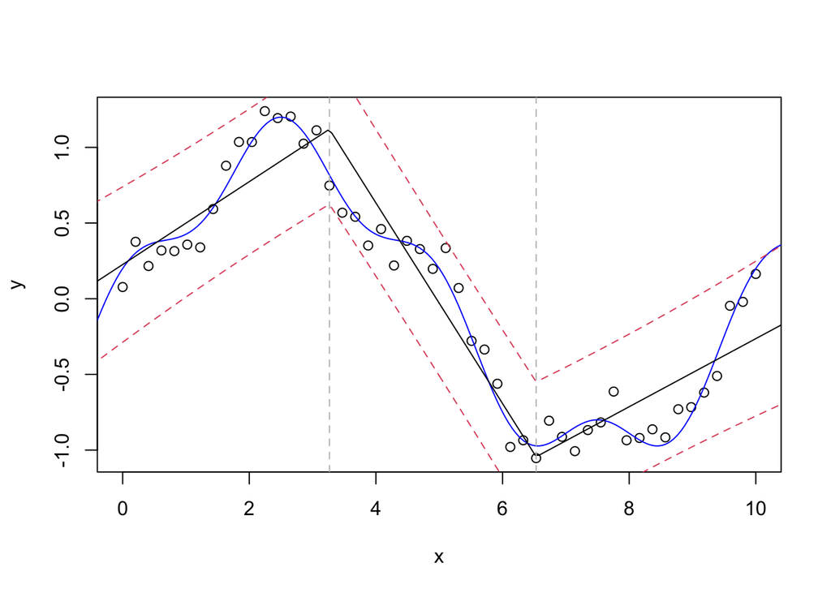

```r
plot(x,y)
lines(xx, yytrue, col="blue")
lines(xx, plc[,1])
lines(xx, plc[,2], col=2, lty=2)
lines(xx, plc[,3], col=2, lty=2)
abline(v=xi, col="gray", lty=2)
```

##### Cubic Splines

```r
H_cs <- data.frame(cbind(rep(1,length(x)), x, x^2, x^3, relu(x-xi[1])^3, relu(x-xi[2])^3))
names(H_cs) <- paste0("x", 1:6)
fit_cs <- lm(y~., data=H_cs)
```

Predict

```r
HH_cs <- data.frame(cbind(rep(1,length(xx)), xx, xx^2, xx^3, relu(xx-xi[1])^3, relu(xx-xi[2])^3))
names(HH_cs) <- paste0("x", 1:6)
pcs <- suppressWarnings(predict(fit_cs, newdata=HH_cs, interval="prediction"))
```

Plot the results

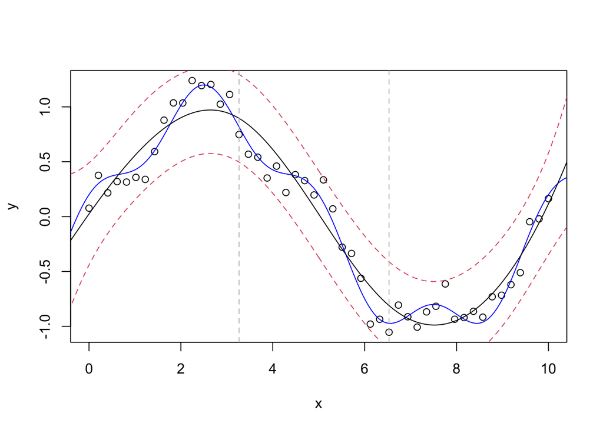

```r
plot(x,y)
lines(xx, yytrue, col="blue")
lines(xx, pcs[,1])
lines(xx, pcs[,2], col=2, lty=2)
lines(xx, pcs[,3], col=2, lty=2)
abline(v=xi, col="gray", lty=2)
```

Bootstrap the results

```r
B <- 1000
YYpred.boot <- matrix(NA, nrow=B, ncol=length(xx))

for (b in 1:B){
  indices <- sample(seq_along(x), length(x), replace=TRUE)
  xi <- x[indices]
  fit <- smooth.spline(xi, y[indices], df=11)
  YYpred.boot[b,] <- as.matrix(predict(fit, data.frame(xi=xx))$y)

}
```

```r
m <- apply(YYpred.boot, 2, mean)
q1 <- apply(YYpred.boot, 2, quantile, p=0.05)
q2 <- apply(YYpred.boot, 2, quantile, p=0.95)
```

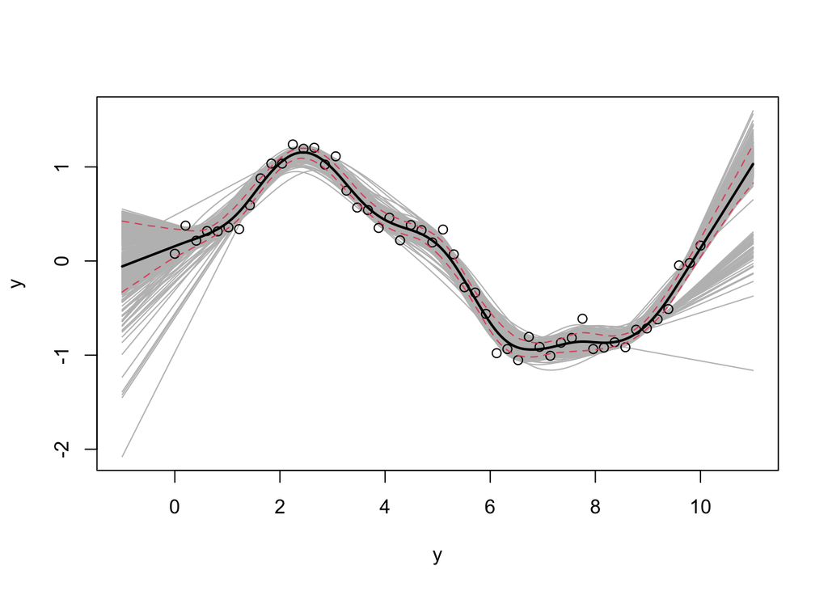

```r
matplot(xx, t(YYpred.boot), type="l", lty=1, col="gray", xlab="y", ylab="y")
points(x, y)
lines(xx, m, lwd=2)
lines(xx, q1, col=2, lty=2)
lines(xx, q2, col=2, lty=2)
```